# Biblioteki Pythona w analizie danych

## Tomasz Rodak

Wykład 4

Literatura:

- [PRML](https://www.microsoft.com/en-us/research/uploads/prod/2006/01/Bishop-Pattern-Recognition-and-Machine-Learning-2006.pdf) Christopher M. Bishop, "Pattern Recognition and Machine Learning", 2006.
- [PML-1](https://probml.github.io/pml-book/) Kevin P. Murphy, "Probabilistic Machine Learning: An Introduction", 2022.
- [Dokumentacja NumPy](https://numpy.org/doc/stable/)

# Regresja logistyczna

Regresja logistyczna to model regresji, który przewiduje prawdopodobieństwo przynależności obserwacji do jednej z dwóch (przypadek binarny) lub więcej (przypadek wieloklasowy) klas.

- W przypadku binarnym prawdopodobieństwo to jest modelowane jako funkcja logistyczna liniowej kombinacji zmiennych objaśniających.
- W przypadku wieloklasowym prawdopodobieństwa przynależności do poszczególnych klas są modelowane poprzez funkcje softmax liniowych kombinacji zmiennych objaśniających.

## Model dla klasyfikacji binarnej

W przypadku klasyfikacji binarnej model regresji logistycznej ma postać:

\begin{equation} P(Y=1|X, \mathbf{w}) = \sigma(\mathbf{w}^T X),\tag{reglog} \end{equation}

gdzie:

- $Y\in\{0,1\}$ jest zmienną binarną,
- $X$ jest wektorem cech,
- $\mathbf{w}$ jest wektorem wag,
- $\sigma$ jest funkcją logistyczną: $\sigma(z) = 1/(1 + \exp(-z))$.

Klasyfikacja polega na przypisaniu obserwacji $\mathbf{x}$ do klasy $1$ jeśli $P(Y=1|\mathbf{x}, \mathbf{w}) > \tau$ dla ustalonego progu $\tau\in(0,1)$. Jeśli $\tau=0.5$, to uzyskuje się aproksymację klasyfikatora Bayesa: obserwację przypisuje się do tej klasy, dla której model przewiduje większe prawdopodobieństwo.

### Funkcja straty i optymalizacja

Optymalizacja regresji logistycznej polega na maksymalizacji funkcji wiarygodności w przestrzeni wag $\mathbf{w}\in\mathbb{R}^{p+1}$, gdzie $p$ to liczba zmiennych objaśniających. Wyznaczony w ten sposób wektor wag $\mathbf{w}_{\text{ML}}$ jest estymatorem największej wiarygodności (MLE) parametrów modelu. W przypadku dwuklasowym funkcja wiarygodności ma postać:

\begin{equation*} \mathcal{L}(\mathbf{w}) = \prod_{i=1}^N P(Y=y_i|X=\mathbf{x}_i, \mathbf{w}) = \prod_{i=1}^N \sigma(\mathbf{w}^T \mathbf{x}_i)^{y_i} (1 - \sigma(\mathbf{w}^T \mathbf{x}_i))^{1-y_i}. \end{equation*}

gdzie $y_i\in\{0,1\}$ jest etykietą $i$-tej obserwacji $\mathbf{x}_i$.

Zwykle zamiast maksymalizacji funkcji wiarygodności minimalizuje się jej ujemny logarytm:

\begin{equation*} \ell(\mathbf{w}) = -\sum_{i=1}^N \left( y_i \log p_i + (1 - y_i) \log (1 - p_i) \right), \end{equation*}

gdzie $p_i = P(Y=1|X=\mathbf{x}_i, \mathbf{w}) = \sigma(\mathbf{w}^T \mathbf{x}_i)$.

Funkcję $\ell$ nazywamy *entropią krzyżową* i jest to funkcja straty dla modelu regresji logistycznej. Łatwo widać, że jest ona różniczkowalna ale można też wykażać, że jest wypukła. Pozwala to na zastosowanie algorytmów optymalizacji gradientowej do jej minimalizacji.

### Granica decyzyjna

Granica decyzyjna w regresji logistycznej jest zbiorem tych $\mathbf{x}\in\mathbb{R}^p$, dla których

\begin{equation*} \tau=P(Y=1|\mathbf{x}, \mathbf{w}) = \sigma(\mathbf{w}^T \mathbf{x}) \end{equation*}

a zatem takich, dla których

\begin{equation*} \mathbf{w}^T \mathbf{x} = \log\left(\frac{\tau}{1-\tau}\right). \end{equation*}

Względem $\mathbf{x}$ powyższe równanie definiuje **hiperpłaszczyznę** w przestrzeni cech, która dzieli przestrzeń na obszary przypisane do klas $0$ i $1$. W szczególności dla $\tau=0.5$ mamy równanie

\begin{equation*} \mathbf{w}^T \mathbf{x} = 0. \end{equation*}

Z tego punktu widzenia regresja logistyczna jest **klasyfikatorem liniowym**, gdyż klasy w przestrzeni cech są rozdzielone liniową granicą decyzyjną.

## Model dla klasyfikacji wieloklasowej

W przypadku klasyfikacji wieloklasowej model regresji logistycznej ma postać:

\begin{equation*} \begin{aligned} P(Y=1|X, \mathbf{W}) &= \frac{\exp(\mathbf{w}_1^T X)}{\sum_{j=1}^K \exp(\mathbf{w}_j^T X)},\\ P(Y=2|X, \mathbf{W}) &= \frac{\exp(\mathbf{w}_2^T X)}{\sum_{j=1}^K \exp(\mathbf{w}_j^T X)},\\ &\ldots\\ P(Y=K|X, \mathbf{W}) &= \frac{\exp(\mathbf{w}_K^T X)}{\sum_{j=1}^K \exp(\mathbf{w}_j^T X)}, \end{aligned} \end{equation*}

gdzie:

- $Y\in\{1,2,\ldots,K\}$ jest zmienną wieloklasową,
- $X$ jest wektorem cech,
- $\mathbf{W} = [\mathbf{w}_1, \mathbf{w}_2, \ldots, \mathbf{w}_K]$ jest macierzą wag.

Klasyfikacja polega na przypisaniu obserwacji $\mathbf{x}$ do klasy $k$ o największym prawdopodobieństwie (zgodnie z klasyfikatorem Bayesa):

\begin{equation*} \hat{Y}(\mathbf{x}) = \underset{k=1,2,\ldots,K}{\operatorname{arg\,max}} P(Y=k|X=\mathbf{x}, \mathbf{W}). \end{equation*}

### Granica decyzyjna

Granica decyzyjna w regresji logistycznej wieloklasowej jest rozwiązaniem układu równań i nierówności linowych. W przypadku dwóch klas granica decyzyjna jest hiperpłaszczyzną, w przypadku wielu klas jest układem fragmentów hiperpłaszczyzn.

### Funkcja straty i optymalizacja

W przypadku klasyfikacji wieloklasowej funkcja straty dla modelu regresji logistycznej ma postać:

\begin{equation*} \ell(\mathbf{W}) = -\sum_{i=1}^N \sum_{k=1}^K I(y_i=k) \log P(Y=k|X=\mathbf{x}_i, \mathbf{W}), \end{equation*}

gdzie $I(y_i=k)$ jest funkcją wskazującą, czy etykieta $y_i$ jest równa $k$. Funkcja ta uogólnia entropię krzyżową z przypadku dwuklasowego. Minimalizacja wymaga zastosowania algorytmów optymalizacji gradientowej.

**Zadanie.** Wykaż, że model regresji logistycznej wieloklasowej jest uogólnieniem modelu regresji logistycznej binarnej.

**Przykład.** Regresja logistyczna dwuklasowa z jedną zmienną objaśniającą.

```python
import numpy as np
import pandas as pd
import matplotlib.pyplot as plt
import seaborn as sns

from sklearn.datasets import make_classification
from sklearn.linear_model import LogisticRegression
from sklearn.metrics import accuracy_score, confusion_matrix
from sklearn.inspection import DecisionBoundaryDisplay
```

```python
X, y = make_classification(n_samples=1000, n_features=1,
                            n_informative=1, n_redundant=0,
                            n_clusters_per_class=1, random_state=42)
model = LogisticRegression()
model.fit(X, y)
y_pred = model.predict(X)
confusion_matrix(y, y_pred)
```

```
array([[462,  40],
       [ 49, 449]])
```

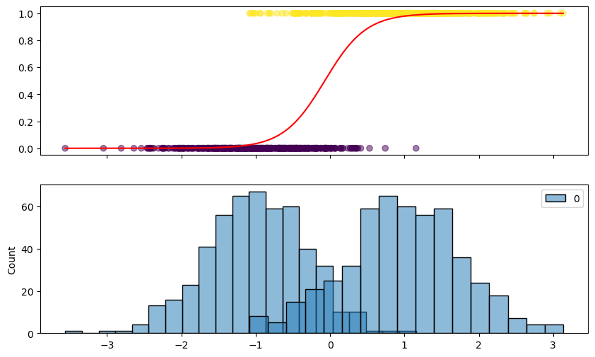

```python
xx = np.linspace(X.min(), X.max(), 1000).reshape(-1, 1)
yy = model.predict_proba(xx)[:, 1]

fig, (ax1, ax2) = plt.subplots(figsize=(10, 6), nrows=2, sharex=True)
ax1.scatter(X, y, alpha=0.5, c=y, cmap='viridis')
ax1.plot(xx, yy, c='r')
sns.histplot(X[y==0], color='green', alpha=.5, ax=ax2)
sns.histplot(X[y==1], color='k', alpha=.5, ax=ax2);
```

**Przykład.** Regresja logistyczna dwuklasowa z dwoma zmiennymi objaśniającymi.

```python
X, y = make_classification(n_samples=1000, n_features=2,
                            n_informative=2, n_redundant=0,
                            n_clusters_per_class=1)
model = LogisticRegression().fit(X, y)
y_pred = model.predict(X)
confusion_matrix(y, y_pred)
```

```
array([[495,   8],
       [ 42, 455]])
```

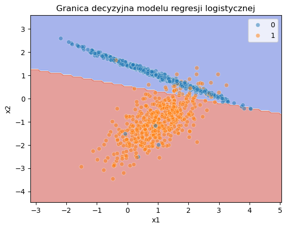

```python
fig, ax = plt.subplots()
DecisionBoundaryDisplay.from_estimator(model, X, response_method="predict", ax=ax, cmap="coolwarm", alpha=.5)
sns.scatterplot(x=X[:,0], y=X[:,1], hue=y, alpha=.5, ax=ax)
ax.set(xlabel="x1", ylabel="x2", title=f"Granica decyzyjna modelu regresji logistycznej");
```

**Przykład.** Regresja logistyczna wieloklasowa z jedną zmienną objaśniającą.

```python
X, y = make_classification(n_samples=1000, n_classes=3,
                           n_features=5, n_informative=2, n_redundant=1, n_repeated=0,
                           n_clusters_per_class=1)

from sklearn.decomposition import PCA
pca = PCA(n_components=1) # rzutujemy na 1 zmienną
X_pca = pca.fit_transform(X)

model = LogisticRegression().fit(X_pca, y)
y_pred = model.predict(X_pca)
confusion_matrix(y, y_pred)
```

```
array([[288,  45,   1],
       [ 53, 253,  26],
       [  1,  25, 308]])
```

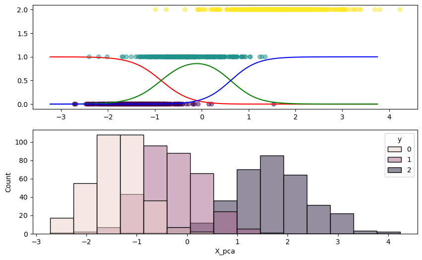

```python
xx = np.linspace(X.min(), X.max(), 1000).reshape(-1, 1)
yy = model.predict_proba(xx)

fig, (ax1, ax2) = plt.subplots(figsize=(10, 6), nrows=2)
ax1.scatter(X_pca, y, alpha=0.5, c=y, cmap='viridis')
ax1.plot(xx, yy[:, 0], c='r')
ax1.plot(xx, yy[:, 1], c='g')
ax1.plot(xx, yy[:, 2], c='b')
sns.histplot(data=pd.DataFrame({
    "X_pca": X_pca.flatten(),
    "y": y
}, columns=["X_pca", "y"]), x="X_pca", hue="y", ax=ax2);
```

**Przykład.** Regresja logistyczna wieloklasowa z dwoma zmiennymi objaśniającymi.

```python
X, y = make_classification(n_samples=1000, n_classes=3,
                           n_features=2, n_informative=2, n_redundant=0, n_repeated=0,
                           n_clusters_per_class=1)
model = LogisticRegression().fit(X, y)
y_pred = model.predict(X)
confusion_matrix(y, y_pred)
```

```
array([[328,   1,   1],
       [  3, 330,   1],
       [  2,   5, 329]])
```

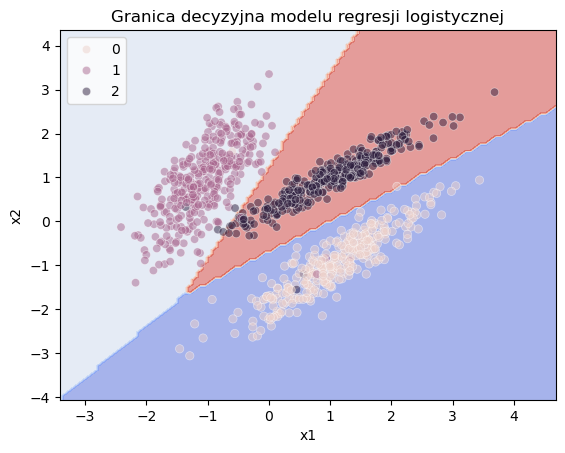

```python
fig, ax = plt.subplots()
DecisionBoundaryDisplay.from_estimator(model, X, response_method="predict", ax=ax, cmap="coolwarm", alpha=.5)
sns.scatterplot(x=X[:,0], y=X[:,1], hue=y, alpha=.5, ax=ax)
ax.set(xlabel="x1", ylabel="x2", title=f"Granica decyzyjna modelu regresji logistycznej");
```

## Modele generatywne w problemach klasyfikacji

W modelu regresji logistycznej obliczamy prawdopodobieństwo warunkowe $P(Y=k|\mathbf{x})$: prawdopodobieństwo tego, że $Y$ przyjmie wartość $k$ jeśli wiadomo, że pojawił się wektor cech $X=\mathbf{x}$.

Można jednak postępować inaczej. Załóżmy, że $Y\in\{1,\ldots,K\}$. Wówczas:

- modelujemy rozkład cech $X$ w każdej z klas $k$, czyli znajdujemy rozkłady warunkowe $p(\mathbf{x}|Y=k)$;
- modelujemy rozkład *a priori* występowania klas $\pi_k=P(Y=k)$;
- wykorzystujemy twierdzenie Bayesa do obliczenia rozkładu *a posteriori* $P(Y=k|\mathbf{x})$:

\begin{equation*} \begin{split} P(Y=k|\mathbf{x}) &= \frac{p(\mathbf{x}|Y=k)P(Y=k)}{p(\mathbf{x})}\\ &= \frac{p(\mathbf{x}|Y=k)P(Y=k)}{\sum_{l=1}^K p(\mathbf{x}|Y=l)P(Y=l)} \end{split} \end{equation*}

Model ten nazywamy *modelem generatywnym*, gdyż pozwala on na generowanie wartości z rozkładu łącznego $p(\mathbf{x}, y):=p(\mathbf{x}|y)p(y)$. W *modelu dyskryminatywnym*, takim jak regresja logistyczna, modelujemy bezpośrednio rozkład $p(y|\mathbf{x})$ pomijając rozkłady warunkowe $p(\mathbf{x}|y)$.

Modele generatywne są bardziej złożone obliczeniowo niż modele dyskryminatywne i wymagają spełnienia dodatkowych założeń. Modelowanie prawdopodobieństw a priori $P(Y=k)$ jest zwykle proste. Jeśli nie mamy żadnych dodatkowych informacji o rozkładzie klas, to przyjmujemy po prostu, że prawdopobieństwo a priori wystąpienia klasy $k$ jest równe częstości występowania tej klasy w zbiorze uczącym:

\begin{equation*} \begin{split} P(Y=k) &= \frac{\text{liczba obserwacji klasy }k}{\text{liczba wszystkich obserwacji}}\\ &=\frac{1}{n}\sum_{i=1}^n I(y_i=k) \end{split} \end{equation*}

Wyznaczenie rozkładów cech w klasach $p(x|Y=k)$ jest zwykle znacznie trudniejsze i wymaga wprowadzenia dodatkowych założeń. W zależności od tego jakie założenia przyjmiemy, otrzymamy różne modele generatywne. Dalej omówimy trzy takie modele: *Linear Discriminant Analysis*, *Quadratic Discriminant Analysis* oraz *Naive Bayes*.

### Linear Discriminant Analysis (LDA)

W modelu LDA zakładamy, że rozkłady cech w klasach są wielowymiarowymi rozkładami normalnymi o nieznanym wektorze średnich $\mu_k$ i nieznanej ale wspólnej macierzy kowariancji $\Sigma$. Wówczas:

\begin{equation*} p(\mathbf{x}|Y=k) = \frac{1}{(2\pi)^{p/2}|\Sigma|^{1/2}}\exp\left(-\frac{1}{2}(\mathbf{x}-\mu_k)^T\Sigma^{-1}(\mathbf{x}-\mu_k)\right), \quad k=1,2,\ldots,K. \end{equation*}

Optymalizacja modelu polega na wyznaczeniu parametrów $\mu_k$ i $\Sigma$ oraz prawdopodobieństw a priori $P(Y=k)$. Dokładne wzory na estymatory MLE tych parametrów znajdziesz w [PRML](https://www.microsoft.com/en-us/research/uploads/prod/2006/01/Bishop-Pattern-Recognition-and-Machine-Learning-2006.pdf), paragraf 4.2.2.

### Quadratic Discriminant Analysis (QDA)

W tym modelu również zakładamy, że rozkłady cech w klasach są wielowymiarowymi rozkładami normalnymi, ale nie zakładamy, że macierz kowariancji jest taka sama dla wszystkich klas. Wówczas:

\begin{equation*} p(\mathbf{x}|Y=k) = \frac{1}{(2\pi)^{p/2}|\Sigma_k|^{1/2}}\exp\left(-\frac{1}{2}(\mathbf{x}-\mu_k)^T\Sigma_k^{-1}(\mathbf{x}-\mu_k)\right), \quad k=1,2,\ldots,K. \end{equation*}

Optymalizacja modelu polega na wyznaczeniu parametrów $\mu_k$ i $\Sigma_k$ dla każdej klasy $k$ oraz prawdopodobieństw a priori $P(Y=k)$.

### Naiwny klasyfikator Bayesa (*Naive Bayes*)

W modela LDA i QDA zakładaliśmy, że rozkłady warunkowe $p(\mathbf{x}|Y=k)$ są rozkładami normalnymi. W obu tych przypadkach szukaliśmy, przy założeniu, że znana jest klasa $k$, rozkładów *łącznych* wektorów losowych $X$. Oznacza to, że szukając rozkładu $X|Y=k$ estymujemy nie tylko rozkłady poszczególnych składowych wektora cech $X_j|Y=k$, ale także kowariancje między nimi. Problem ten ulega znacznemu uproszczeniu w naiwnym klasyfikatorze Bayesa (*Naive Bayes*), w którym zakładamy, że cechy $X_j$ są niezależne, gdy znamy klasę $k$. Wówczas warunkowy rozkład łączny $X|Y=k$ jest iloczynem rozkładów warunkowych poszczególnych składowych $X_j|Y=k$:

$$ p(\mathbf{x}|Y=k) = \prod_{j=1}^p p(x_j|Y=k). $$

Założenie o niezależności cech jest bardzo silne i rzadko jest spełnione w rzeczywistych problemach. Jednak w wielu przypadkach, nawet gdy to założenie nie jest spełnione naiwny klasyfikator Bayesa daje dobre wyniki.

Rozkład a posteriori ma wówczas postać:

$$ P(Y=k|\mathbf{x}) = \frac{P(Y=k)\prod_{j=1}^p p(x_j|Y=k)}{\sum_{l=1}^K P(Y=l)\prod_{j=1}^p p(x_j|Y=l)}. $$

Aby zakończyć budowę modelu musimy zdefiniować rozkłady warunkowe $p(x_j|Y=k)$ dla każdej cechy $X_j$ i każdej klasy $k$. W tym celu możemy wykorzystać dowolny rozkład prawdopodobieństwa. Najczęściej stosuje się rozkłady normalne, Bernoulliego lub wielomianowe.

- Jeśli cecha $X_j$ jest zmienną losową ciągłą, to możemy przyjąć, że $(X_j|Y=k)\sim N(\mu_{jk}, \sigma_{jk}^2)$, gdzie $\mu_{jk}$ i $\sigma_{jk}^2$ są parametrami rozkładu normalnego dla cechy $X_j$ i klasy $k$. Wówczas rozkład warunkowy $p(\mathbf{ x}|Y=k)$ jest rozkładem normalnym o gęstości $N(\mu_k, \Sigma_k)$, gdzie $\mu_k = (\mu_{1k}, \ldots, \mu_{pk})^T$ jest wektorem średnich cech dla klasy $k$, a $\Sigma_k$ jest **diagonalną** macierzą kowariancji cech dla klasy $k$ (wymaga obliczenia $p$ parametrów $\sigma_{jk}^2$ na głównej przekątnej, poza nią macierz jest zerowa).
- Inna opcja dla zmiennej losowej ciągłej to zdefiniowanie rozkładu $p(x_j|Y=k)$ na podstawie histogramu lub estymatora jądrowego.
- Jeśli cecha $X_j$ jest kategoryjna (ma skończony zbiór wartości), to prawdopoobieństwo $p(x_j|Y=k)$ możemy estymować na podstawie częstości występowania poszczególnych wartości cechy $X_j$ w klasie $k$.

## Metody klasyfikacji - porównanie

Ustalmy klasę $K$ jako punkt odniesienia i rozważmy logarytmy stosunków prawdopodobieństw:

$$ \log\frac{P(Y=k|x)}{P(Y=K|x)},\qquad k=1,\ldots,K. $$

Obserwację $x$ przypisujemy do klasy $k$, dla której logarytm ten jest największy. W przypadku modelu LDA mamy

\begin{align*} \log\frac{P(Y=k|x)}{P(Y=K|x)} &= \log\frac{P(Y=k)}{P(Y=K)} + \log\frac{p(x|Y=k)}{p(x|Y=K)} \\ &= \log\frac{P(Y=k)}{P(Y=K)} - \frac{1}{2}(\mu_k+\mu_K)^T\Sigma^{-1}(\mu_k-\mu_K) + x^T\Sigma^{-1}(\mu_k-\mu_K)\\ &= a_k +\sum_{j=1}^p b_{kj}x_j, \end{align*}

gdzie $a_k$ i $b_{kj}$ są stałymi niezależnymi od $x$. Zatem logarytmy szans w modelu LDA są funkcjami liniowymi względem $x$ dokładnie tak samo jak w przypadku regresji logistycznej. Różnica między tymi modelami polega na tym, że w regresji logistycznej szukamy parametrów $a_k$ i $b_{kj}$ bezpośrednio, natomiast w modelu LDA obliczamy najpierw parametry $P(Y=k)$, $\mu_k$ i $\Sigma$ i dopiero na ich podstawie uzyskujemy parametry $a_k$ i $b_{kj}$. Zatem w modelu regresji logistycznej mamy mniej parametrów do dopasowania niż w modelu LDA. Ponadto w tym pierwszym przypadku nic nie zakładamy na temat postaci rozkładów warunkowych $p(x|Y=k)$ modelując od razu rozkład $P(Y=k|x)$. Jeśli spodziewamy się, że rozkłady warunkowe $p(x|Y=k)$ są rozkładami normalnymi, to model LDA może być lepszym wyborem niż regresja logistyczna. W przeciwnym przypadku wybieramy regresję logistyczną jako bardziej uniwersalny i mniej kosztowny obliczeniowo model.

W modelu QDA mamy

\begin{align*} \log\frac{P(Y=k|x)}{P(Y=K|x)} &= a_k +\sum_{j=1}^p b_{kj}x_j + \sum_{j=1}^p\sum_{l=1}^p c_{kjl}x_jx_l, \end{align*}

gdzie $a_k$, $b_{kj}$ i $c_{kjl}$ znów nie zależą od $x$ i są funkcjami parametrów modelu $P(Y=k)$, $\mu_k$ i $\Sigma_k$. Logarytmy szans w modelu QDA są funkcjami kwadratowymi względem $x$.

W naiwnym klasyfikatorze Bayesa mamy

\begin{align*} \log\frac{P(Y=k|x)}{P(Y=K|x)} &= \log\frac{P(Y=k)}{P(Y=K)} + \sum_{j=1}^p\log\frac{p(x_j|Y=k)}{p(x_j|Y=K)} \\ &= a_k +\sum_{j=1}^p g_{kj}(x_j), \end{align*}

gdzie $a_k=\log(P(Y=k)/P(Y=K))$ i $g_{kj}(x_j)=\log(p(x_j|Y=k)/p(x_j|Y=K))$.

Z powyższych przedstawień wynika:

- QDA sprowadza się do LDA, gdy $c_{kjl}=0$ dla wszystkich $k$, $j$ i $l$. Dzieje się tak dokładnie wtedy, gdy wszystkie macierze kowariancji $\Sigma_k$ są równe.
- Kładąc $g_{kj}(x_j)=b_{kj}x_j$ w naiwnym klasyfikatorze Bayesa otrzymujemy model LDA z niezależnymi cechami (macierz kowariancji $\Sigma$ jest diagonalna).
- QDA nie sprowadza się do naiwnego klasyfikatora Bayesa, ani naiwny klasyfikator Bayesa nie sprowadza się do QDA. W modelu Naive Bayes cechy są warunkowo niezależne, ale mogą być modelowana dowolnymi rozkładami. Z kolei w modelu QDA cechy mogą być skorelowane, ponadto model uwzględnia interakcje między nimi.